# Differential Gene Expression and Preliminary ORA

BCB420 Assignment 2

Li Quan Soh

2024-03-07

# 1 Differential Gene Expression

#### Include necessary packages

## 1.1 Summary of my Dataset

**IMPORTANT DISCLAIMER**: For this assignment, I was initially working with the filtered and normalized datasets from A1. However, it came to my attention that 2 of the samples (MI-503 Replicate #3 and DMSO Replicate #3) were not grouped properly in the MDS plot (figure below). I subsequently performed DGE analysis on the data and looked at the heatmap (figures below). It was especially evident in DMSO vs Combination where I noticed DMSO Replicate #3 incorrectly grouped with the Combinations samples. I checked my initial datasets and procedures conducted in A1 and find no errors. Thus, I suspect there might be mislabeling of the samples. With the advice of Professor Isserlin, I removed them as I re-do the filtering, normalization and DGE analysis.

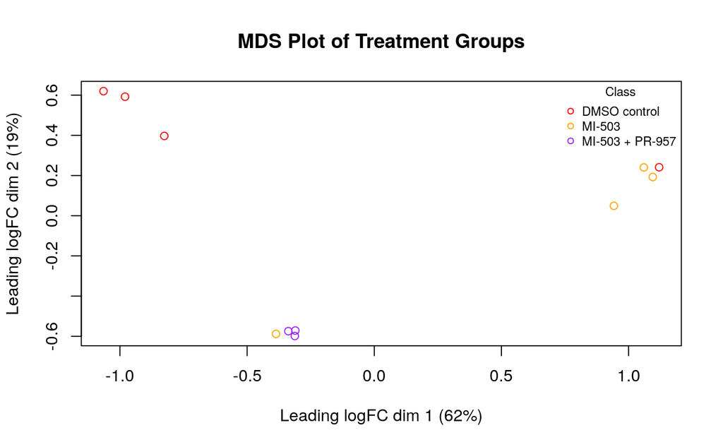

***

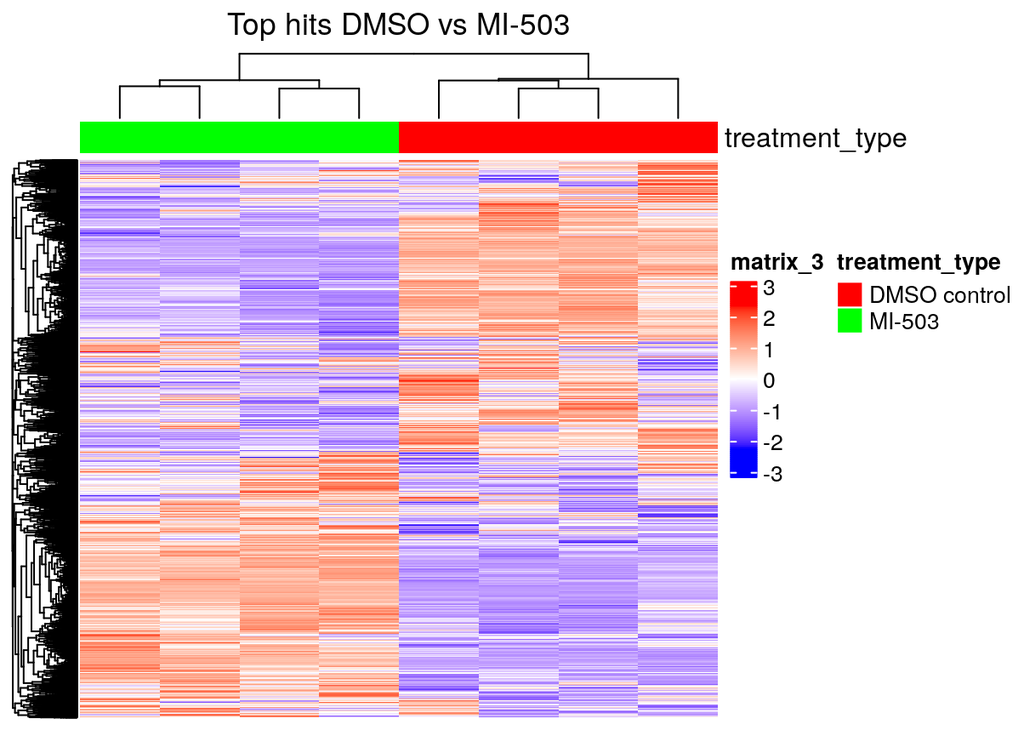

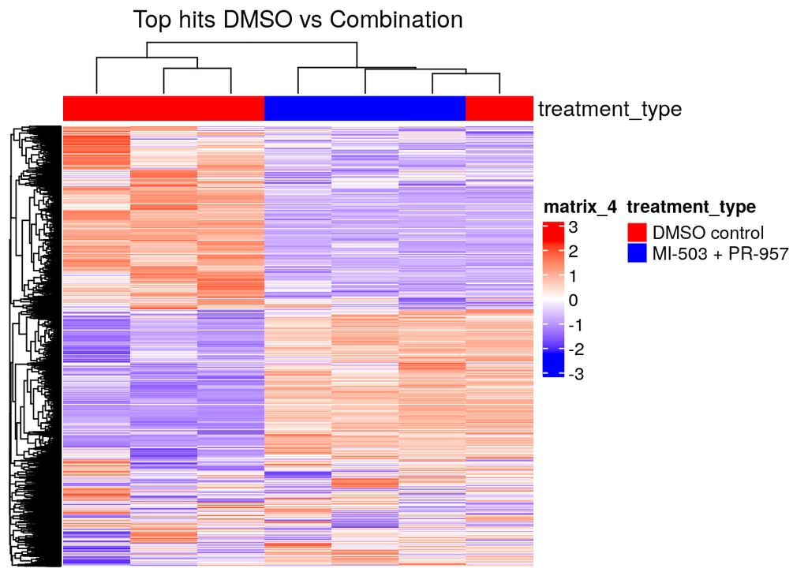

**Updated Summary**:

The following figure shows the difference in my dataset pre- and post-filtering.

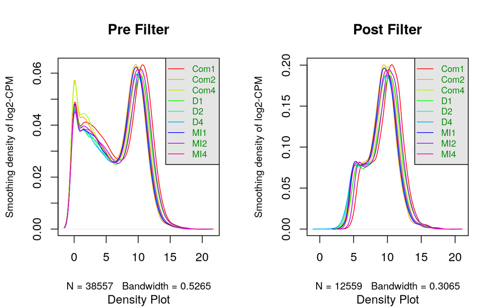

The following figure shows the difference in my dataset pre- and post-normalization.

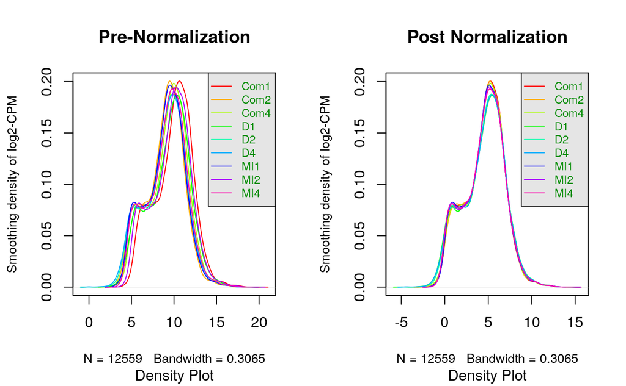

## 1.2 Conducting Differential Expression Analysis via edgeR

#### Model Design

I first need to consider which factor(s) to include in my model. Considering that all variables besides *Treatment* are uniform across the samples, I will have to design the model with *Treatment*.

The MDS plot generated in Assignment 1 is shown below. There is great separation between the groups (DMSO vs MI-503 vs Combination). As a reminder, the 2 problematic samples are removed.

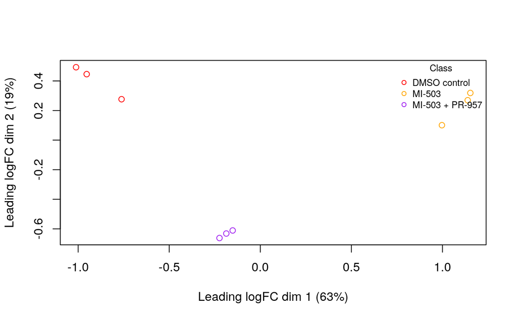

Since *Treatment* has 3 groups, I will split the dataset to do two 2-group comparisons: * Comparison 1: DMSO vs MI-503 * Comparison 2: DMSO vs Combination (MI-503 + PR-957)

```r
# Create design matrix for Comparison 1 (DMSO vs MI-503)
treatment1 = samples_info_dt$Treatment[-c(7:9)]
model_design1 <- model.matrix(~treatment1)
model_design1[1:5,]
```

```
  (Intercept) treatment1MI-503
1           1                0
2           1                0
3           1                0
4           1                1
5           1                1
```

```r
# Create design matrix for Comparison 2 (DMSO vs Combination)
treatment2 = samples_info_dt$Treatment[-c(4:6)]
model_design2 <- model.matrix(~treatment2)
model_design2[1:5,]
```

```
  (Intercept) treatment2MI-503 + PR-957
1           1                         0
2           1                         0
3           1                         0
4           1                         1
5           1                         1
```

#### Construct the model

```r
# create DGElist object for Comparison 1 and Comparison 2
d1 = DGEList(counts=filtered_data_matrix[,-c(1:3)], group=treatment1)
d2 = DGEList(counts=filtered_data_matrix[,-c(7:9)], group=treatment2)

# calculate normalization factors
d1 = calcNormFactors(d1)
d2 = calcNormFactors(d2)

# estimate dispersion with our model design
d1 <- estimateDisp(d1, model_design1)
d2 <- estimateDisp(d2, model_design2)

# fit the model
fit1 <- glmQLFit(d1, model_design1)
fit2 <- glmQLFit(d2, model_design2)

# calculate differential expression using Quasi Likelihood model
qlf.DMSO_vs_MI503 <- glmQLFTest(fit1, coef='treatment1MI-503')
qlf.DMSO_vs_Combination <- glmQLFTest(fit2, coef='treatment2MI-503 + PR-957')

# Table of the top differentially expressed genes
kable(topTags(qlf.DMSO_vs_MI503), type="html", row.names = TRUE)
```

|  | logFC | logCPM | F | PValue | FDR |
| --- | --- | --- | --- | --- | --- |
| MEF2C | -1.948524 | 6.983074 | 2181.477 | 0 | 0 |
| SORL1 | 2.958179 | 5.731389 | 1990.321 | 0 | 0 |
| LYZ | 2.007811 | 7.892505 | 1744.596 | 0 | 0 |
| PTGER4 | 2.158293 | 5.080236 | 1741.341 | 0 | 0 |
| REEP3 | -1.424899 | 6.645184 | 1508.367 | 0 | 0 |
| CHI3L1 | 2.210211 | 8.433800 | 1379.439 | 0 | 0 |
| TSPOAP1 | 1.429227 | 10.005962 | 1310.328 | 0 | 0 |
| PBX3 | -1.943104 | 5.615888 | 1284.375 | 0 | 0 |
| PRAM1 | 1.857708 | 6.623563 | 1247.557 | 0 | 0 |
| SOCS2 | -1.407503 | 7.214247 | 1228.793 | 0 | 0 |

|  | x |
| --- | --- |
| 1 | BH |

|  | x |
| --- | --- |
| 1 | treatment1MI-503 |

|  | x |
| --- | --- |
| 1 | glm |

```r
kable(topTags(qlf.DMSO_vs_Combination), type="html", row.names = TRUE)
```

|  | logFC | logCPM | F | PValue | FDR |
| --- | --- | --- | --- | --- | --- |
| FAM219A | -3.498176 | 5.525700 | 1791.9816 | 0 | 0e+00 |
| GABARAPL1 | -3.144915 | 4.784043 | 1454.1864 | 0 | 1e-07 |
| SLC48A1 | -2.406202 | 5.577152 | 1176.3704 | 0 | 1e-07 |
| FLYWCH1 | -1.595112 | 6.533468 | 1161.7420 | 0 | 1e-07 |
| CYB5R1 | -2.070657 | 5.471889 | 1064.6537 | 0 | 1e-07 |
| REEP3 | 1.481577 | 6.667486 | 1016.7174 | 0 | 1e-07 |
| UNKL | -1.837206 | 6.015454 | 1001.8516 | 0 | 1e-07 |
| MIR1915HG | 2.148533 | 5.089451 | 970.9325 | 0 | 1e-07 |
| IL7R | -3.832016 | 4.029748 | 935.6927 | 0 | 1e-07 |
| STOX2 | -2.410992 | 5.214740 | 927.5659 | 0 | 1e-07 |

|  | x |
| --- | --- |
| 1 | BH |

|  | x |
| --- | --- |
| 1 | treatment2MI-503 + PR-957 |

|  | x |
| --- | --- |
| 1 | glm |

## 1.3 DGE Analysis

For both Comparison 1 and Comparsion 2, we want to determine how many genes pass the threshold p-value of 0.05 and pass the correction.

```r
# Get the results for both comparisons
qlf_outputHits1 <- topTags(qlf.DMSO_vs_MI503,
                           sort.by = "PValue",
                           adjust.method = "BH",
                           n = nrow(normalized_counts))

qlf_outputHits2 <- topTags(qlf.DMSO_vs_Combination,
                           sort.by = "PValue",
                           adjust.method = "BH",
                           n = nrow(normalized_counts))

# Number of genes that pass threshold p-val of < .05
num_passThreshold1 <- length(which(qlf_outputHits1$table$PValue < 0.05))
num_passThreshold2 <- length(which(qlf_outputHits2$table$PValue < 0.05))

# Number of genes that pass B-Hcorrection
num_passCorrection1 <- length(which(qlf_outputHits1$table$FDR < 0.05))
num_passCorrection2 <- length(which(qlf_outputHits2$table$FDR < 0.05))
```

| Comparison Group | # of genes that have p-val < .05 | # of genes that pass B-H correction |
| --- | --- | --- |
| DMSO vs MI-503 | 7824 | 7300 |
| DMSO vs Combination | 8298 | 7800 |

It appears that there are more genes that are differentially expressed in *DMSO vs Combination* than *DMSO vs MI-503*, controlling for the false discovery rate via B-H correction.

#### MA Plot Visualization of DGE Result

MA Plot for DMSO vs MI-503 and DMSO vs Combination. Significant genes are colored red.

```r
par(mfrow = c(1,2))

# Create MA plot for DMSO vs MI-503
plot(qlf_outputHits1$table$logCPM, qlf_outputHits1$table$logFC,
     pch=20,
     col = ifelse(qlf_outputHits1$table$PValue < 0.05, "red", "black"),
     xlab = "logCPM", ylab = "logFC",
     main = "MA Plot: DMSO vs MI-503")


# Legend
legend("topright",
       legend = c("Not Sig", "Sig (p < 0.05)"),
       col = c("black", "red"),
       pch = 20)
```

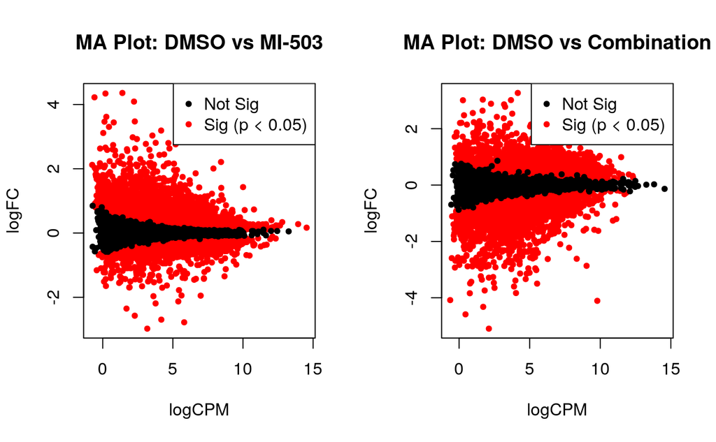

```r
# Create MA plot for DMSO vs Combination
plot(qlf_outputHits2$table$logCPM, qlf_outputHits2$table$logFC,
     pch=20,
     col = ifelse(qlf_outputHits2$table$PValue < 0.05, "red", "black"),
     xlab = "logCPM", ylab = "logFC",
     main = "MA Plot: DMSO vs Combination")


# Legend
legend("topright",
       legend = c("Not Sig", "Sig (p < 0.05)"),
       col = c("black", "red"),
       pch = 20)
```

I am using MA plots to illustrate the log fold-change versus mean expression between two treatments. It is a bit odd that there are so many differentially expressed genes that pass the significance threshold. At the very least, the shape of the MA plot looks normal to an extent. Perhaps using an even smaller threshold (p < 0.01) may have been a better choice to isolate the highly differential genes.

#### Heatmap Visualization

Comparison 1: DMSO vs MI-503

```r
library(grid)
library(ComplexHeatmap)
library(circlize)

# Heatmap matrix for DMSO vs MI-503
heatmap_matrix1 <- normalized_counts[,-c(1:3)]

#row-normalization
heatmap_matrix1 <- t(scale(t(heatmap_matrix1)))

rownames(heatmap_matrix1) <- rownames(normalized_counts)
colnames(heatmap_matrix1) <- colnames(normalized_counts[,-c(1:3)])

# subsetting the heatmap matrix to only include top hits
top_hits1 <- rownames(qlf_outputHits1$table)[qlf_outputHits1$table$PValue < 0.05]

heatmap_matrix_tophits1 <- t(scale(t(heatmap_matrix1[which(rownames(heatmap_matrix1) %in% top_hits1),])))

if(min(heatmap_matrix_tophits1) == 0){
  heatmap_col1 = colorRamp2(c(0, max(heatmap_matrix_tophits1)),
                              c("white", "red"))
} else {
  heatmap_col1 = colorRamp2(c(min(heatmap_matrix_tophits1), 0, max(heatmap_matrix_tophits1)),
                            c("blue", "white", "red"))
}

# Annotations to visualize data clusters
unique_treatment <- unique(samples_info_dt$Treatment)
unique_treatment_col <- rainbow(n = length(unique_treatment))
names(unique_treatment_col) <- unique_treatment

ha1 <- HeatmapAnnotation(df = data.frame(treatment_type = treatment1),
  col = list(treatment_type = unique_treatment_col),
  show_legend = TRUE
)

# Actual heatmap for DMSO vs MI-503.
current_heatmap1 <- Heatmap(as.matrix(heatmap_matrix1), top_annotation = ha1,
                            cluster_rows = TRUE, cluster_columns = TRUE,
                            show_row_dend = TRUE, show_column_dend = TRUE,
                            col = heatmap_col1, show_heatmap_legend = TRUE,
                            show_row_names = FALSE, show_column_names = FALSE,
                            column_title = "Top hits DMSO vs MI-503"
                            )
```

Comparison 2: DMSO vs Combination (MI-503 + PR-957)

```r
# Heatmap matrix for DMSO vs Combination
heatmap_matrix2 <- normalized_counts[,-c(7:9)]

#row-normalization
heatmap_matrix2 <- t(scale(t(heatmap_matrix2)))

rownames(heatmap_matrix2) <- rownames(normalized_counts)
colnames(heatmap_matrix2) <- colnames(normalized_counts[,-c(7:9)])

# subsetting the heatmap matrix to only include top hits
top_hits2 <- rownames(qlf_outputHits2$table)[qlf_outputHits2$table$PValue < 0.05]

heatmap_matrix_tophits2 <- t(scale(t(heatmap_matrix2[which(rownames(heatmap_matrix2) %in% top_hits2),])))

if(min(heatmap_matrix_tophits2) == 0){
  heatmap_col2 = colorRamp2(c(0, max(heatmap_matrix_tophits2)),
                              c("white", "red"))
} else {
  heatmap_col2 = colorRamp2(c(min(heatmap_matrix_tophits2), 0, max(heatmap_matrix_tophits2)),
                            c("blue", "white", "red"))
}

# Annotations to visualize data clusters
unique_treatment <- unique(samples_info_dt$Treatment)
unique_treatment_col <- rainbow(n = length(unique_treatment))
names(unique_treatment_col) <- unique_treatment

ha2 <- HeatmapAnnotation(df = data.frame(treatment_type = treatment2),
  col = list(treatment_type = unique_treatment_col),
  show_legend = TRUE
)

# Actual heatmap for DMSO vs Combination
current_heatmap2 <- Heatmap(as.matrix(heatmap_matrix2), top_annotation = ha2,
                            cluster_rows = TRUE, cluster_columns = TRUE,
                            show_row_dend = TRUE, show_column_dend = TRUE,
                            col = heatmap_col1, show_heatmap_legend = TRUE,
                            show_row_names = FALSE, show_column_names = FALSE,
                            column_title = "Top hits DMSO vs Combination"
                            )
```

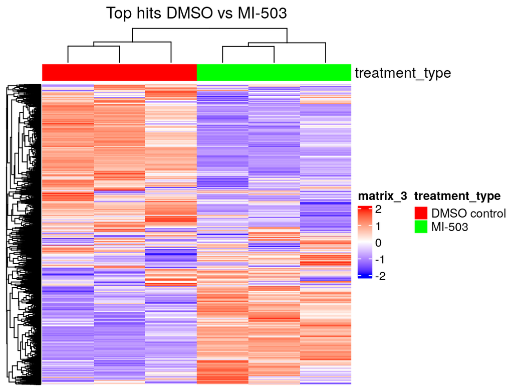

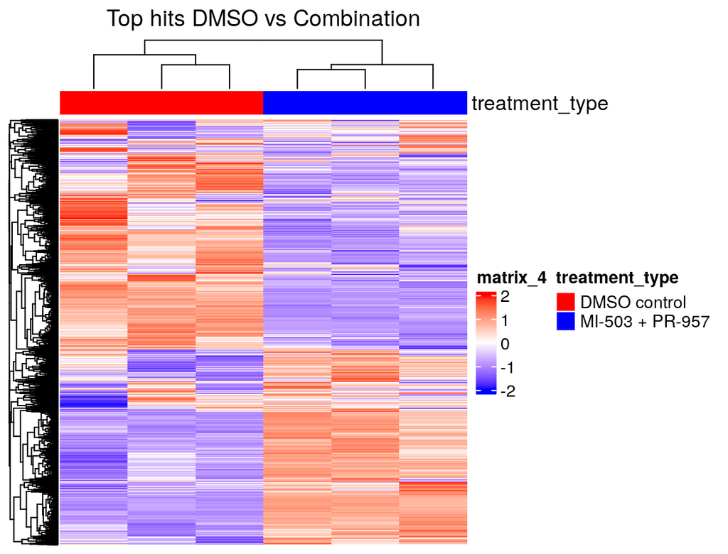

The Heatmap shows that the groups are clustered properly based on treatment_type, and there are clear clustering of genes that up-regulate and down-regulated together.

# 2 Thresholded ORA

## 2.2 Analyzing Changes in Gene Expression between Treatment Groups

```r
# Significant fold-changes genes in DMSO vs MI-503 DGE
up_comparison1 <- length(which(qlf_outputHits1$table$PValue < 0.05 &
                                 qlf_outputHits1$table$logFC > 0))

down_comparison1 <- length(which(qlf_outputHits1$table$PValue < 0.05 &
                                   qlf_outputHits1$table$logFC < 0))

# Significant fold-changes genes in DMSO vs Combination DGE
up_comparison2 <- length(which(qlf_outputHits2$table$PValue < 0.05 &
                                 qlf_outputHits2$table$logFC > 0))

down_comparison2 <- length(which(qlf_outputHits2$table$PValue < 0.05 &
                                   qlf_outputHits2$table$logFC < 0))
```

| Comparison Group | Upregulated Genes Count | Downregulated Genes Count |
| --- | --- | --- |
| DMSO vs MI-503 | 3978 | 3846 |
| DMSO vs Combination | 4082 | 4216 |

## 2.3 Construct Thresholded List of Genes

```r
# DMSO vs MI-503
# merge top hits with gene names
qlf_outputHits1_HGNC <- merge(filtered_data_matrix_HGNC[,1:2],
                              qlf_outputHits1, by.x=1, by.y=0)
# remove genes that don't have HGNC symbols
qlf_outputHits1_HGNC <-
  qlf_outputHits1_HGNC[which(!is.na(qlf_outputHits1_HGNC$hgnc_symbol)),]

upreg_genes1 <- qlf_outputHits1_HGNC$hgnc_symbol[
  which(qlf_outputHits1_HGNC$PValue < 0.05 &
          qlf_outputHits1_HGNC$logFC > 0)]

downreg_genes1 <- qlf_outputHits1_HGNC$hgnc_symbol[
  which(qlf_outputHits1_HGNC$PValue < 0.05 &
          qlf_outputHits1_HGNC$logFC < 0)]

write.table(x = upreg_genes1,
            file = file.path(getwd(), "DMSOvMI-503_upregulated_genes.txt"),
            sep = "\t", row.names = FALSE,
            col.names = FALSE, quote = FALSE)

write.table(x = downreg_genes1,
            file = file.path(getwd(), "DMSOvMI-503_downregulated_genes.txt"),
            sep = "\t", row.names = FALSE,
            col.names = FALSE, quote = FALSE)
```

```r
# DMSO vs Combination
# merge top hits with gene names
qlf_outputHits2_HGNC <- merge(filtered_data_matrix_HGNC[,1:2],
                              qlf_outputHits2, by.x=1, by.y=0)
# remove genes that don't have HGNC symbols
qlf_outputHits2_HGNC <-
  qlf_outputHits2_HGNC[which(!is.na(qlf_outputHits2_HGNC$hgnc_symbol)),]

upreg_genes2 <- qlf_outputHits2_HGNC$hgnc_symbol[
  which(qlf_outputHits2_HGNC$PValue < 0.05 &
          qlf_outputHits2_HGNC$logFC > 0)]

downreg_genes2 <- qlf_outputHits2_HGNC$hgnc_symbol[
  which(qlf_outputHits2_HGNC$PValue < 0.05 &
          qlf_outputHits2_HGNC$logFC < 0)]

# save themm to txt file
write.table(x = upreg_genes2,
            file = file.path(getwd(), "DMSOvCombination_upregulated_genes.txt"),
            sep = "\t", row.names = FALSE,
            col.names = FALSE, quote = FALSE)

write.table(x = downreg_genes2,
            file = file.path(getwd(), "DMSOvCombination_downregulated_genes.txt"),
            sep = "\t", row.names = FALSE,
            col.names = FALSE, quote = FALSE)
```

## 2.4 Thresholded Over-Representation Analysis via G:Profiler

1. Method chosen: G:Profiler
2. Annotation data: GO:Biological Pathway, Reactome, WikiPathways (current versions)
3. Number of genesets returned: 1503 for DMSO v Combination (figure below)

ORA for DMSO vs MI-503

```r
library(gprofiler2)
# ORA for both up-regulated and down-regulated genes
gprofiler_results_both1 <- gost(query = c(upreg_genes1, downreg_genes1),
                                 significant=FALSE,
                                 ordered_query = FALSE,
                                 exclude_iea=TRUE,
                                 correction_method = "fdr",
                                 organism = "hsapiens",
                                 source = c("REAC","WP","GO:BP"))

# ORA for up-regulated genes subset
gprofiler_results_upreg1 <- gost(query = upreg_genes1,
                                 significant=FALSE,
                                 ordered_query = FALSE,
                                 exclude_iea=TRUE,
                                 correction_method = "fdr",
                                 organism = "hsapiens",
                                 source = c("REAC","WP","GO:BP"))

# ORA for down-regulated genes subset
gprofiler_results_downreg1 <- gost(query = downreg_genes1,
                                 significant=FALSE,
                                 ordered_query = FALSE,
                                 exclude_iea=TRUE,
                                 correction_method = "fdr",
                                 organism = "hsapiens",
                                 source = c("REAC","WP","GO:BP"))

kable(gprofiler_results_both1$result[1:4,], type="html", row.names = TRUE,
      caption = "Query Result for DMSO vs MI-503 (All Differentially Expressed Genes)")
```

Query Result for DMSO vs MI-503 (All Differentially Expressed Genes)

|  | query | significant | p_value | term_size | query_size | intersection_size | precision | recall | term_id | source | term_name | effective_domain_size | source_order | parents |
| --- | --- | --- | --- | --- | --- | --- | --- | --- | --- | --- | --- | --- | --- | --- |
| 1 | query_1 | TRUE | 0 | 9757 | 6304 | 4415 | 0.7003490 | 0.4524956 | GO:0008152 | GO:BP | metabolic process | 16178 | 3159 | GO:0008150 |
| 2 | query_1 | TRUE | 0 | 8309 | 6304 | 3858 | 0.6119924 | 0.4643158 | GO:0006807 | GO:BP | nitrogen compound metabolic process | 16178 | 2516 | GO:0008152 |
| 3 | query_1 | TRUE | 0 | 8726 | 6304 | 4013 | 0.6365799 | 0.4598900 | GO:0044238 | GO:BP | primary metabolic process | 16178 | 11300 | GO:0008152 |
| 4 | query_1 | TRUE | 0 | 9325 | 6304 | 4228 | 0.6706853 | 0.4534048 | GO:0071704 | GO:BP | organic substance metabolic process | 16178 | 17374 | GO:0008152 |

```r
kable(gprofiler_results_upreg1$result[1:4,], type="html", row.names = TRUE,
      caption = "Query Result for DMSO vs MI-503 (Up-Regulated Genes)")
```

Query Result for DMSO vs MI-503 (Up-Regulated Genes)

|  | query | significant | p_value | term_size | query_size | intersection_size | precision | recall | term_id | source | term_name | effective_domain_size | source_order | parents |
| --- | --- | --- | --- | --- | --- | --- | --- | --- | --- | --- | --- | --- | --- | --- |
| 1 | query_1 | TRUE | 0 | 1258 | 2963 | 350 | 0.1181235 | 0.2782194 | GO:0016192 | GO:BP | vesicle-mediated transport | 16178 | 5229 | GO:00068…. |
| 2 | query_1 | TRUE | 0 | 3336 | 2963 | 788 | 0.2659467 | 0.2362110 | GO:0048583 | GO:BP | regulation of response to stimulus | 16178 | 13279 | GO:00507…. |
| 3 | query_1 | TRUE | 0 | 154 | 2963 | 74 | 0.0249747 | 0.4805195 | GO:0002181 | GO:BP | cytoplasmic translation | 16178 | 736 | GO:0006412 |
| 4 | query_1 | TRUE | 0 | 2537 | 2963 | 618 | 0.2085724 | 0.2435948 | GO:0009966 | GO:BP | regulation of signal transduction | 16178 | 3842 | GO:00071…. |

```r
kable(gprofiler_results_downreg1$result[1:4,], type="html", row.names = TRUE,
      caption = "Query Result for DMSO vs MI-503 (Down-Regulated Genes)")
```

Query Result for DMSO vs MI-503 (Down-Regulated Genes)

|  | query | significant | p_value | term_size | query_size | intersection_size | precision | recall | term_id | source | term_name | effective_domain_size | source_order | parents |
| --- | --- | --- | --- | --- | --- | --- | --- | --- | --- | --- | --- | --- | --- | --- |
| 1 | query_1 | TRUE | 0 | 827 | 3341 | 463 | 0.1385813 | 0.5598549 | GO:0006396 | GO:BP | RNA processing | 16178 | 2181 | GO:00104…. |
| 2 | query_1 | TRUE | 0 | 5519 | 3341 | 1707 | 0.5109249 | 0.3092952 | GO:0034641 | GO:BP | cellular nitrogen compound metabolic process | 16178 | 9002 | GO:00068…. |
| 3 | query_1 | TRUE | 0 | 8309 | 3341 | 2254 | 0.6746483 | 0.2712721 | GO:0006807 | GO:BP | nitrogen compound metabolic process | 16178 | 2516 | GO:0008152 |
| 4 | query_1 | TRUE | 0 | 5130 | 3341 | 1550 | 0.4639330 | 0.3021442 | GO:0046483 | GO:BP | heterocycle metabolic process | 16178 | 12593 | GO:0044237 |

ORA for DMSO vs Combination

```r
gprofiler_results_both2 <- gost(query = c(upreg_genes2, downreg_genes2),
                                 significant=FALSE,
                                 ordered_query = FALSE,
                                 exclude_iea=TRUE,
                                 correction_method = "fdr",
                                 organism = "hsapiens",
                                 source = c("REAC","WP","GO:BP"))

# ORA for up-regulated genes subset
gprofiler_results_upreg2 <- gost(query = upreg_genes2,
                                 significant=FALSE,
                                 ordered_query = FALSE,
                                 exclude_iea=TRUE,
                                 correction_method = "fdr",
                                 organism = "hsapiens",
                                 source = c("REAC","WP","GO:BP"))

# ORA for down-regulated genes subset
gprofiler_results_downreg2 <- gost(query = downreg_genes2,
                                 significant=FALSE,
                                 ordered_query = FALSE,
                                 exclude_iea=TRUE,
                                 correction_method = "fdr",
                                 organism = "hsapiens",
                                 source = c("REAC","WP","GO:BP"))

kable(gprofiler_results_both2$result[1:4,], type="html", row.names = TRUE,
      caption = "Query Result for DMSO vs Combination (All Differentially Expressed Genes)")
```

Query Result for DMSO vs Combination (All Differentially Expressed Genes)

|  | query | significant | p_value | term_size | query_size | intersection_size | precision | recall | term_id | source | term_name | effective_domain_size | source_order | parents |
| --- | --- | --- | --- | --- | --- | --- | --- | --- | --- | --- | --- | --- | --- | --- |
| 1 | query_1 | TRUE | 0 | 9757 | 6531 | 4573 | 0.7001991 | 0.4686891 | GO:0008152 | GO:BP | metabolic process | 16178 | 3159 | GO:0008150 |
| 2 | query_1 | TRUE | 0 | 8309 | 6531 | 3981 | 0.6095544 | 0.4791190 | GO:0006807 | GO:BP | nitrogen compound metabolic process | 16178 | 2516 | GO:0008152 |
| 3 | query_1 | TRUE | 0 | 8726 | 6531 | 4145 | 0.6346654 | 0.4750172 | GO:0044238 | GO:BP | primary metabolic process | 16178 | 11300 | GO:0008152 |
| 4 | query_1 | TRUE | 0 | 9325 | 6531 | 4377 | 0.6701883 | 0.4693834 | GO:0071704 | GO:BP | organic substance metabolic process | 16178 | 17374 | GO:0008152 |

```r
kable(gprofiler_results_upreg2$result[1:4,], type="html", row.names = TRUE,
      caption = "Query Result for DMSO vs Combination (Up-Regulated Genes)")
```

Query Result for DMSO vs Combination (Up-Regulated Genes)

|  | query | significant | p_value | term_size | query_size | intersection_size | precision | recall | term_id | source | term_name | effective_domain_size | source_order | parents |
| --- | --- | --- | --- | --- | --- | --- | --- | --- | --- | --- | --- | --- | --- | --- |
| 1 | query_1 | TRUE | 0 | 5519 | 3442 | 1740 | 0.5055200 | 0.3152745 | GO:0034641 | GO:BP | cellular nitrogen compound metabolic process | 16178 | 9002 | GO:00068…. |
| 2 | query_1 | TRUE | 0 | 8651 | 3442 | 2365 | 0.6871005 | 0.2733788 | GO:0044237 | GO:BP | cellular metabolic process | 16178 | 11299 | GO:00081…. |
| 3 | query_1 | TRUE | 0 | 5130 | 3442 | 1589 | 0.4616502 | 0.3097466 | GO:0046483 | GO:BP | heterocycle metabolic process | 16178 | 12593 | GO:0044237 |
| 4 | query_1 | TRUE | 0 | 827 | 3442 | 430 | 0.1249274 | 0.5199516 | GO:0006396 | GO:BP | RNA processing | 16178 | 2181 | GO:00104…. |

```r
kable(gprofiler_results_downreg2$result[1:4,], type="html", row.names = TRUE,
      caption = "Query Result for DMSO vs Combination (Down-Regulated Genes)")
```

Query Result for DMSO vs Combination (Down-Regulated Genes)

|  | query | significant | p_value | term_size | query_size | intersection_size | precision | recall | term_id | source | term_name | effective_domain_size | source_order | parents |
| --- | --- | --- | --- | --- | --- | --- | --- | --- | --- | --- | --- | --- | --- | --- |
| 1 | query_1 | TRUE | 0 | 1258 | 3090 | 415 | 0.1343042 | 0.3298887 | GO:0016192 | GO:BP | vesicle-mediated transport | 16178 | 5229 | GO:00068…. |
| 2 | query_1 | TRUE | 0 | 2145 | 3090 | 623 | 0.2016181 | 0.2904429 | GO:0009056 | GO:BP | catabolic process | 16178 | 3269 | GO:0008152 |
| 3 | query_1 | TRUE | 0 | 490 | 3090 | 193 | 0.0624595 | 0.3938776 | GO:0006914 | GO:BP | autophagy | 16178 | 2592 | GO:00442…. |
| 4 | query_1 | TRUE | 0 | 490 | 3090 | 193 | 0.0624595 | 0.3938776 | GO:0061919 | GO:BP | process utilizing autophagic mechanism | 16178 | 16215 | GO:0009987 |

Figure illustrating gene-sets that pass threshold using different queries: all DEG vs up-regulated genes vs down-regulated genes

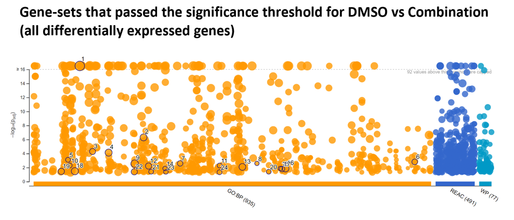

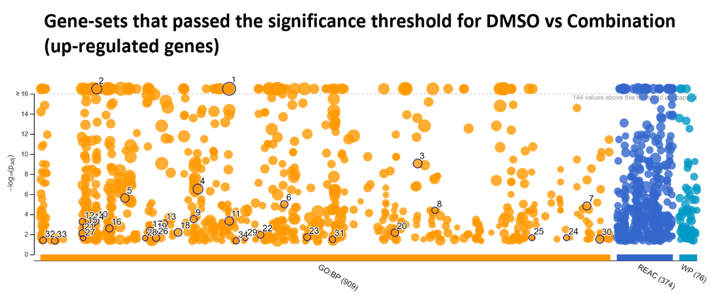

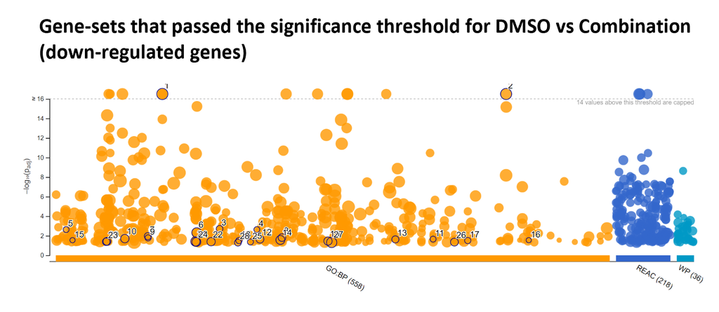

As expected, a huge portion of the gene-sets come from GO annotation. The top most significantly-enriched terms for DMSO vs Combination are of the following:

1. Using all DEG as query:
- GO:BP
  - DNA replication
  - sister chromatid segregation
  - mitochondrial gene expression
- Reactome
  - Mitotic Metaphase and Anaphase
  - Mitotic Anaphase
  - S Phase
- WikiPathways
  - Retinoblastoma gene in cancer
  - mRNA processing
  - DNA repair pathways full network
2. Using Up-regulated genes as query:
- GO:BP
  - mitochondrial gene expression
  - mitochondrial translation
  - rRNA metabolic process
- Reactome
  - mRNA Splicing
  - mRNA Splicing - Major Pathway
  - Mitochondrial translation elongation
- WikiPathways
  - Retinoblastoma gene in cancer
  - mRNA processing
  - Cell cycle
3. Using Down-regulated genes as query:
- GO:BP
  - vacuole organization
  - vacuolar transport
  - lysosomal transport
- Reactome
  - Nuclear events mediated by NFE2L2
  - KEAP1-NFE2L2 pathway
  - Antigen processing-Cross presentation
- WikiPathways
  - TYROBP causal network in microglia
  - Proteasome degradation
  - Degradation pathway of sphingolipids including diseases

# 3 Interpretations and Conclusions

1. Do the over-representation results support conclusions or mechanism discussed in the original paper? The over-representation results do support the conclusions discussed in the original paper (Tubı́o-Santamarı́a et al. 2023), to a certain degree. Based on the key terms in the ORA for DMSO vs Combination, the DEGs and up-regulated genes share some common pathways and GO terms, which are related to the gene expression pathway and cell cycle. These are expected since the article (Tubı́o-Santamarı́a et al. 2023) is looking for gene targets that reduce the proliferation of AML (cancer). Interestingly, the down-regulated genes have terms that are more different from the DEGs and up-regulated genes. Proteasome degradation term was enriched in WikiPathways, which supports the article that reduction in proteasome helps reduce proliferation of AML.
2. Can you find evidence, i.e. publications, to support some of the results that you see. How does this evidence support your results. BASP1 is up-regulated in my DEG Analysis. This is supported by other publications (Zhou et al. 2018), which confirms that the silencing of BASP1 leads to leukemogenesis in AML. Thus, the treatment of Pr-957+MI-503 up-regulates the BASP1 gene expression, which in turn reduces the proliferation of AML.

**Conclusions**

On my initial workflow, I noticed issues with the MDS plot, heatmap clustering, and number of differentially expressed genes. I make the decision to remove the problematic samples per the advice of Professor Isserlin, and re-do filtering and normalization. In this assignment, I have successfully conducted differential gene expression analysis via EdgeR, as well as preliminary thresholded over-representation analysis via G:Profiler.

Tubı́o-Santamarı́a, Nuria, Ashok Kumar Jayavelu, Tina M Schnoeder, Theresa Eifert, Chen-Jen Hsu, Florian Perner, Qirui Zhang, et al. 2023. “Immunoproteasome Function Maintains Oncogenic Gene Expression in KMT2A-Complex Driven Leukemia.” *Molecular Cancer* 22 (1): 196.

Zhou, Lei, Lin Fu, Na Lv, Jing Liu, Yan Li, Xiaosu Chen, Qingyu Xu, et al. 2018. “Methylation-Associated Silencing of BASP1 Contributes to Leukemogenesis in t (8; 21) Acute Myeloid Leukemia.” *Experimental & Molecular Medicine* 50 (4): 1–8.